# Gene Expression Prediction Challenge (expred)

Azat Aleksanyan, Lucas Chabeau, Matthieu François, Etienne Hamard

2019-04-17

## Présentation des données

Afin d’être familiarisés avec les données il nous a fallut au préalable comprendre nos données principales. Nous avons 21 gènes impliqués dans 7 processus biologiques différents :

Le gène ATAD2 qui encode une enzyme qui transforme les macro protéines, et le gène SYCP3 qui encode une enzyme du complexe synaptonémal formé entre les chromosomes homologues. Ces deux enzymes constituent en partie les chromatines, structure au sein de laquelle l’ADN se trouve empaquetée et compactée dans le volume limité du noyau des cellules eucaryotes. Les gènes H19, IGF2, NNAT, BLCAP qui encodent des enzymes impliquées dans la régulation de la masse corporelle et le développement du corps et du cerveau font partie de la famille des gènes soumis à empreinte, c’est à dire que la copie héritée de la mère et la copie héritée du père ne sont pas exprimées de la même manière. Les gènes BRD4, BRDT, NUTM1 encodent des protéines qui associent les chromosomes durant la mitose. Les gènes TUBA3C, MAGEB6 jouent un rôle important dans la spermatogénèse. Les gènes SMYD3, MAP3K2, KDR encodent des enzymes faisant partie de la famille des méthyltransférases, un groupe d’enzymes qui transfèrent un groupe méthyle d’un donneur à un accepteur. Les gènes KRAS, BRAF encodent des enzymes oncogènes et le gène TP53 est impliqué dans la régulation du cycle cellulaire. Les gènes FASTKD1, ND2, ND3, ND4 encodent des enzymes responsables de l’activité mitochondriale.

## A : Méthodes statistiques utilisées

### **Statistiques descriptives**

Nous commençons l’exploration de nos données par l’observation des statistiques élémentaires ainsi que le nombre de valeur manquantes pour chaque variable.

#### **Variables quantitatives**

```
#>       age            ATAD2            SYCP3             BRDT
#>  Min.   :14.58   Min.   : 6.163   Min.   : 0.000   Min.   : 0.000
#>  1st Qu.:51.32   1st Qu.: 9.928   1st Qu.: 2.732   1st Qu.: 0.000
#>  Median :61.22   Median :10.781   Median : 3.672   Median : 1.279
#>  Mean   :59.92   Mean   :10.769   Mean   : 3.742   Mean   : 1.905
#>  3rd Qu.:70.16   3rd Qu.:11.672   3rd Qu.: 4.651   3rd Qu.: 2.527
#>  Max.   :90.06   Max.   :15.286   Max.   :11.698   Max.   :12.824
#>                  NA's   :971      NA's   :972      NA's   :938
#>       BRD4            NUTM1            MAGEB6          TUBA3C
#>  Min.   : 8.997   Min.   : 0.000   Min.   :0.000   Min.   : 0.0000
#>  1st Qu.:12.072   1st Qu.: 0.000   1st Qu.:0.000   1st Qu.: 0.0000
#>  Median :12.403   Median : 1.192   Median :0.000   Median : 0.0000
#>  Mean   :12.463   Mean   : 1.550   Mean   :0.566   Mean   : 0.9201
#>  3rd Qu.:12.797   3rd Qu.: 2.346   3rd Qu.:0.000   3rd Qu.: 1.2208
#>  Max.   :16.623   Max.   :12.057   Max.   :9.245   Max.   :12.9165
#>  NA's   :947      NA's   :928      NA's   :992     NA's   :934
#>       H19              IGF2             NNAT            BLCAP
#>  Min.   : 0.000   Min.   : 2.818   Min.   : 0.000   Min.   : 8.46
#>  1st Qu.: 7.442   1st Qu.: 9.269   1st Qu.: 4.225   1st Qu.:11.72
#>  Median : 9.352   Median :10.732   Median : 5.357   Median :12.20
#>  Mean   : 9.323   Mean   :11.194   Mean   : 5.678   Mean   :12.21
#>  3rd Qu.:11.132   3rd Qu.:12.567   3rd Qu.: 6.636   3rd Qu.:12.63
#>  Max.   :19.964   Max.   :22.528   Max.   :17.059   Max.   :16.34
#>  NA's   :922      NA's   :998      NA's   :953      NA's   :920
#>      SMYD3            MAP3K2            KDR              TP53
#>  Min.   : 4.944   Min.   : 7.776   Min.   : 5.208   Min.   : 5.838
#>  1st Qu.: 7.867   1st Qu.:11.087   1st Qu.: 9.220   1st Qu.:11.079
#>  Median : 8.400   Median :11.596   Median :10.252   Median :11.722
#>  Mean   : 8.461   Mean   :11.533   Mean   :10.364   Mean   :11.599
#>  3rd Qu.: 8.998   3rd Qu.:12.050   3rd Qu.:11.377   3rd Qu.:12.269
#>  Max.   :13.575   Max.   :14.524   Max.   :15.942   Max.   :14.792
#>  NA's   :1015     NA's   :877      NA's   :945      NA's   :954
#>       KRAS             BRAF           FASTKD1            ND2
#>  Min.   : 7.229   Min.   : 7.287   Min.   : 5.530   Min.   : 7.892
#>  1st Qu.:10.689   1st Qu.:10.082   1st Qu.: 9.309   1st Qu.:16.522
#>  Median :11.193   Median :10.673   Median : 9.706   Median :17.288
#>  Mean   :11.196   Mean   :10.574   Mean   : 9.710   Mean   :17.339
#>  3rd Qu.:11.683   3rd Qu.:11.133   3rd Qu.:10.116   3rd Qu.:18.171
#>  Max.   :17.610   Max.   :15.093   Max.   :12.444   Max.   :22.602
#>  NA's   :936      NA's   :918      NA's   :996      NA's   :975
#>       ND3              ND4
#>  Min.   : 8.127   Min.   : 9.106
#>  1st Qu.:15.096   1st Qu.:17.955
#>  Median :15.816   Median :18.679
#>  Mean   :15.894   Mean   :18.721
#>  3rd Qu.:16.658   3rd Qu.:19.486
#>  Max.   :21.292   Max.   :24.167
#>  NA's   :954      NA's   :955
```

#### **Variables qualitatives**

Ci-dessous un tri à plat de nos variables qualitatives

```
#> $sex
#> x
#>    F    M
#> 4693 4417
#>
#> $tissue_status
#> x
#>  normal tumoral
#>     611    8499
#>
#> $project
#> x
#>  TCGA-ACC TCGA-BLCA TCGA-BRCA TCGA-CHOL TCGA-COAD TCGA-DLBC TCGA-ESCA
#>        78       376      1151        39       411        27       167
#>  TCGA-GBM TCGA-HNSC TCGA-KICH TCGA-KIRC TCGA-KIRP  TCGA-LGG TCGA-LIHC
#>       140       496        81       501       281       494       395
#> TCGA-LUAD TCGA-LUSC TCGA-MESO   TCGA-OV TCGA-PAAD TCGA-PCPG TCGA-PRAD
#>       456       474        80       341       151       162       512
#> TCGA-READ TCGA-SARC TCGA-SKCM TCGA-STAD TCGA-TGCT TCGA-THCA TCGA-THYM
#>       137       231        91       391       133       535       115
#> TCGA-UCEC  TCGA-UCS  TCGA-UVM
#>       529        56        79
#>
#> $tissue
#> x
#>                     adnexa              adrenal_gland
#>                         79                        224
#>                adult_ovary                    bladder
#>                        341                        376
#>                      brain                     breast
#>                        634                       1151
#>              bronchus_lung                      colon
#>                        930                        411
#>         connective_tissues                  esophagus
#>                        113                        167
#>                     kidney                     larynx
#>                        863                        111
#>                      liver                lymph_nodes
#>                        434                         27
#>                mediastinum                      mouth
```

[output cut: 37 more lines]

```
#> $tnm_stage
#> x
#>        I I/II NOS       IA       IB       II      IIA      IIB      IIC
#>     1070        1      315      301      530      706      603       49
#>      III     IIIA     IIIB     IIIC       IS       IV      IVA      IVB
#>      582      440      215      175       46      388      304       15
#>      IVC        X     <NA>
#>        6       11     3353
#>
#> $tnm_grade
#> x
#>         G1         G2         G3         G4         GB         GX
#>        250       1222       1494         79          2         29
#> High Grade  Low Grade       <NA>
#>        348         21       5665
```

Nous voyons pas mal de valeurs manquantes sur pas mal de variables ici : cependant, nous n’avons aucune valeur manquante sur la localisation du gène (tissue), son état (tumoral ou normal), le programme suivi par le patient ainsi que son sexe, ces informations vont être intéressantes dans la construction du modèle.

Il y a à peu près autant que d’hommes que de femmes dans notre étude et la grande majorité des tissus présentent une tumeur.

#### **Lien entre les variables**

Avant de commencer une modélisation, il est toujours intéressant de regarder la matrice des corrélations :

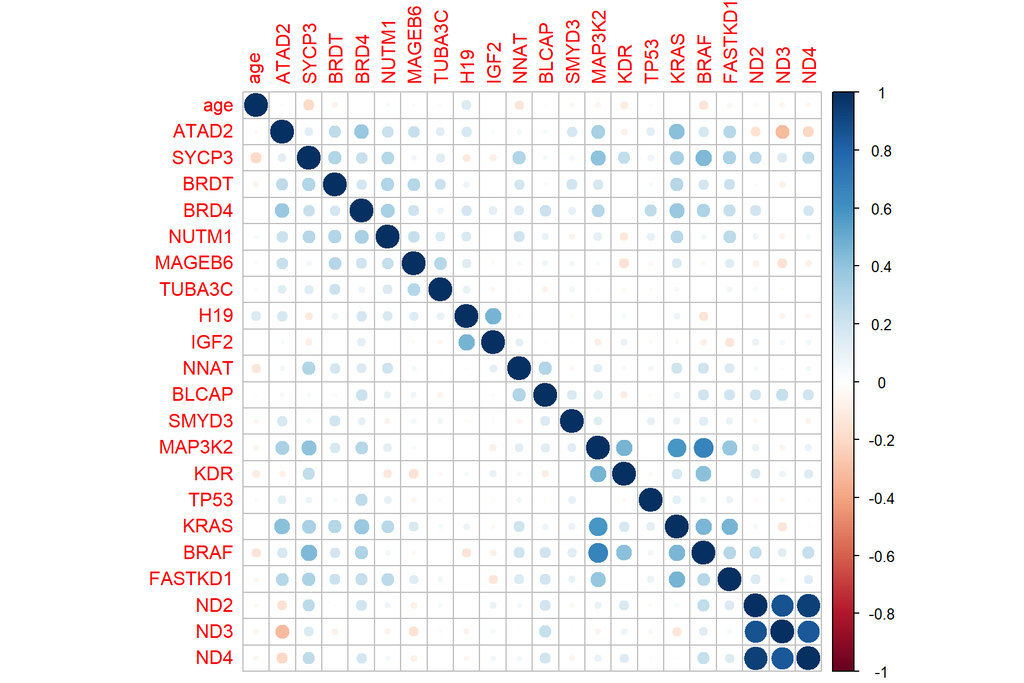

```
#>                  age       ATAD2       SYCP3         BRDT          BRD4
#> age      1.000000000  0.02041557 -0.19310351 -0.064192660 -0.0072059676
#> ATAD2    0.020415565  1.00000000  0.12485091  0.255249456  0.3704415520
#> SYCP3   -0.193103515  0.12485091  1.00000000  0.295858194  0.2267671811
#> BRDT    -0.064192660  0.25524946  0.29585819  1.000000000  0.1892047313
#> BRD4    -0.007205968  0.37044155  0.22676718  0.189204731  1.0000000000
#> NUTM1    0.034623047  0.21592674  0.28575513  0.295511784  0.3218924180
#> MAGEB6   0.020339802  0.22416329  0.05550252  0.280767783  0.2020659276
#> TUBA3C   0.025463421  0.13070842  0.13554786  0.213256856  0.0772622101
#> H19      0.158187698  0.17190728 -0.11151419  0.072700116  0.1868832465
#> IGF2     0.006947358  0.02893432 -0.08689073 -0.009466628  0.1181821393
#> NNAT    -0.132535735  0.05269346  0.29223291  0.181678340  0.1577768407
#> BLCAP   -0.018321311  0.04133821  0.03891446  0.028627228  0.2182952939
#> SMYD3   -0.042689385  0.17679146  0.04974435  0.197946019  0.1056053771
#> MAP3K2  -0.057571288  0.32028590  0.40718859  0.178085535  0.2881050478
#> KDR     -0.106967538 -0.07563619  0.24844603  0.005787931 -0.0009488449
#> TP53     0.029434518  0.12704817  0.07144621  0.033254339  0.2553928312
#> KRAS    -0.006585968  0.41972178  0.32336826  0.289662392  0.3765986602
#> BRAF    -0.144574963  0.17518460  0.44604501  0.188435927  0.3081216862
#> FASTKD1 -0.048582428  0.28085474  0.31320713  0.213600473  0.2386163503
#> ND2     -0.032567871 -0.15594852  0.26243106  0.018172741  0.1960321952
#> ND3     -0.056645671 -0.31955691  0.15537905 -0.073737248  0.0012282840
#> ND4     -0.044744225 -0.20104939  0.25902422 -0.009255776  0.1813266159
#>                NUTM1      MAGEB6        TUBA3C          H19         IGF2
#> age      0.034623047  0.02033980  0.0254634205  0.158187698  0.006947358
#> ATAD2    0.215926742  0.22416329  0.1307084164  0.171907285  0.028934321
#> SYCP3    0.285755133  0.05550252  0.1355478574 -0.111514187 -0.086890728
#> BRDT     0.295511784  0.28076778  0.2132568561  0.072700116 -0.009466628
#> BRD4     0.321892418  0.20206593  0.0772622101  0.186883247  0.118182139
#> NUTM1    1.000000000  0.23681142  0.1556178637  0.164097459  0.007083093
#> MAGEB6   0.236811424  1.00000000  0.2884203124  0.141240100 -0.023686546
#> TUBA3C   0.155617864  0.28842031  1.0000000000  0.099920334 -0.043290409
#> H19      0.164097459  0.14124010  0.0999203341  1.000000000  0.464721565
#> IGF2     0.007083093 -0.02368655 -0.0432904093  0.464721565  1.000000000
#> NNAT     0.209291660  0.04532045  0.0139284407 -0.015034323  0.113820717
#> BLCAP    0.093617482  0.06900216 -0.0689237360 -0.003260342  0.017447391
#> SMYD3   -0.064085443  0.05377083  0.0582145386 -0.026189547 -0.013589589
#> MAP3K2   0.117656924  0.03385169  0.0176770012  0.007550329 -0.088489458
#> KDR     -0.124757091 -0.15297794 -0.0322469009  0.036358300  0.092071816
#> TP53     0.108298269 -0.04853885 -0.0212358030  0.007693238 -0.024500066
```

[output cut: 60 more lines]

```
#> TUBA3C  -0.023260001  0.010618020
#> H19     -0.067594841 -0.047925418
#> IGF2     0.047989582  0.051665528
#> NNAT    -0.015904260  0.050405258
#> BLCAP    0.239979090  0.197369212
#> SMYD3    0.010071019 -0.064427776
#> MAP3K2  -0.060157107  0.088518775
#> KDR      0.076392922  0.143785073
#> TP53    -0.044978026 -0.016997760
#> KRAS    -0.133471234  0.016193307
#> BRAF     0.131003167  0.238252508
#> FASTKD1  0.048294060  0.143143171
#> ND2      0.863267479  0.936656428
#> ND3      1.000000000  0.847908021
#> ND4      0.847908021  1.000000000
```

Nous avons donc les expressions des gènes ND2, ND3 et ND4 qui sont positivement très corrélées (corrélation > 0.84 à chaque fois)

Nous devons aussi noter la corrélation entre les expressions des gènes MP3K2 et BRAF (> 0.66) et celle entre MP3K2 et KRAS (> 0.58)

### Méthodes utilisées pour notre modélisation

Dans un premier temps nous avons utilisé le modèle mis à disposition dans l’énoncé qui permettait de prédire chaque gène en fonction de l’âge et du sexe du candidat, le tissu cancérigène, son statut, et le projet d’étude associé. Afin d’améliorer ces 21 modèles similaires (21 expressions de gènes à modéliser), nous avons décidé d’ajouter un “step()” dans le code. Cela permettant d’affiner chaque régression linéaire, en supprimant les variables qui n’ont pas d’impact sur la valeur du gène choisit. Pour être plus précis, nous avons utilisé la méthode “backward”" pour séléctionner notre modèle“.

Dans un second temps, pour aller plus loin dans la prédiction, nous nous sommes dit que ce qui pouvait expliquer la valeur d’expression d’un gène pouvait être la valeur d’expression des gènes de la même famille ou même des gènes en général. Nous avons donc cherché à inclure la valeur d’expression des gènes de notre jeu de données pour prédire ceux ci. Il a fallut donc procéder en deux étapes, la première étant d’imputer les valeurs manquantes une première fois pour avoir un jeu de données complet. La seconde étant de réaliser un nouveau modèle en exprimant chaque gène à nouveau avec les variables précédemment utilisées mais en y ajoutant les gènes restants (puis d’affiner le modèle comme précédemment). Pour la première étape nous avons décidé d’imputer les valeurs manquantes de chaque gène par les valeurs prédites lors du deuxième modèle fait précédemment. Etant données le faible taux d’erreur obtenu (observé sur codalab) cette imputation semblait judicieuse. Ensuite il n’a suffit que d’appliquer la méthode classique de régression linéaire multiple.

Le tableau suivant résume pour chaque gène quel paramètre est utilisé dans la modélisation (marqué par une croix) :

|  | sex | tissue_status | project | tissue | ATAD2 | SYCP3 | H19 | IGF2 | NNAT | BLCAP | BRD4 | BRDT | NUTM1 | MAGEB6 | TUBA3C | SMYD3 | MAP3K2 | KDR | TP53 | KRAS | BRAF | FASTKD1 | ND2 | ND3 | ND4 |
| --- | --- | --- | --- | --- | --- | --- | --- | --- | --- | --- | --- | --- | --- | --- | --- | --- | --- | --- | --- | --- | --- | --- | --- | --- | --- |
| ATAD2 | x | x | x | x |  |  | x | x | x | x | x | x |  | x | x | x | x | x | x | x | x | x | x | x |  |
| SYCP3 |  | x | x | x | x |  | x | x | x | x |  | x | x |  | x | x | x |  | x | x | x | x | x |  | x |
| H19 |  | x | x | x | x | x |  | x | x | x | x |  | x | x | x | x | x | x | x |  | x |  | x |  |  |
| IGF2 |  | x | x | x | x |  | x | x |  | x |  | x | x | x |  | x | x | x | x |  | x | x | x | x | x |
| NNAT |  |  | x | x | x | x |  | x | x |  | x | x |  | x | x | x | x | x |  |  | x | x |  | x | x |
| BLCAP | x | x | x | x | x |  | x | x | x | x | x | x | x |  | x |  |  | x | x | x | x |  |  | x | x |
| BRD4 | x |  | x |  | x | x | x | x |  | x |  | x | x | x |  | x | x | x | x | x |  |  | x |  | x |
| BRDT |  |  | x | x | x | x |  | x | x |  | x |  |  | x | x | x | x | x |  | x | x |  |  | x | x |
| NUTM1 | x | x | x | x | x |  | x |  | x | x | x | x | x | x | x | x | x | x | x | x |  | x |  |  | x |
| MAGEB6 |  | x | x | x | x | x | x | x |  | x |  | x | x | x |  | x | x | x | x | x | x | x | x | x |  |
| TUBA3C | x | x | x | x | x | x |  | x | x |  | x | x |  | x | x | x | x | x | x | x |  | x | x | x |  |
| SMYD3 | x | x | x | x | x | x | x | x | x | x | x | x | x |  | x |  | x | x | x | x | x | x | x | x | x |
| MAP3K2 |  | x | x |  | x | x | x | x | x | x | x | x | x | x | x | x |  | x | x | x | x | x | x | x | x |
| KDR |  | x | x | x | x |  | x | x | x | x | x | x | x | x | x | x | x |  |  |  | x | x | x | x | x |
| TP53 |  | x | x | x | x | x |  | x | x | x | x | x |  | x | x | x | x |  |  | x | x |  | x |  | x |
| KRAS |  |  | x | x | x | x | x | x | x | x |  |  |  | x | x | x | x |  |  |  | x | x | x | x | x |
| BRAF | x | x | x | x | x | x | x |  | x |  | x | x | x | x |  | x | x | x | x | x |  | x | x | x | x |
| FASTKD1 |  |  | x | x | x | x |  | x | x | x | x | x | x |  |  | x | x | x |  | x | x |  | x | x | x |
| ND2 |  | x | x |  | x |  |  |  | x | x | x | x |  |  | x | x | x | x | x | x | x | x |  | x | x |
| ND3 |  | x | x | x | x |  | x |  | x | x | x |  | x | x |  | x | x | x |  | x | x | x | x |  | x |
| ND4 |  | x | x |  |  | x | x | x |  |  | x |  | x | x | x | x | x | x | x | x | x | x | x | x |  |

Le modèle précédant a tout de même pour limite de contenir des variables explicatives corréllées entre elles. Nous avons donc recommencé un nouveau modèle avec la méthode suivante :

- La méthode d’imputation des valeurs manquantes chez l’expression des gènes est restée la même à une différence près : pour les gènes ND2, ND3, ND4 nous avons imputé par une régression linéaire entre eux (ND2~ND4; ND3~ND2; ND4~ND2), en effet ces variables sont très coréllées, ça nous a donc semblé sensé d’utiliser cette méthode.
- Nous avons ensuite à nouveau fait une modélisation linéaire multiple pour chaque gène. Nous sommes partis du modèle complet en ne gardant qu’une seule des variables explicatives corrélées entre elle, nous gardons à chaque fois la plus corréllé à la variable à expliquer. A partir de ce modèle “complet”, méthode backward pour séléctionner le modèle.

Revoici donc le tableau des variables explicatives pour chaque modèle avec cette méthode.

|  | sex | tissue_status | project | tissue | ATAD2 | SYCP3 | H19 | IGF2 | NNAT | BLCAP | BRD4 | BRDT | NUTM1 | MAGEB6 | TUBA3C | SMYD3 | MAP3K2 | KDR | TP53 | KRAS | BRAF | FASTKD1 | ND2 | ND3 | ND4 |
| --- | --- | --- | --- | --- | --- | --- | --- | --- | --- | --- | --- | --- | --- | --- | --- | --- | --- | --- | --- | --- | --- | --- | --- | --- | --- |
| ATAD2 | x | x | x | x |  |  | x | x | x | x | x | x |  | x | x | x | x | x | x | x |  | x |  | x |  |
| SYCP3 |  | x | x | x |  |  | x | x | x | x |  | x | x |  | x | x |  |  | x | x | x | x | x |  |  |
| H19 |  | x | x | x |  | x | x | x | x | x | x |  | x | x | x | x |  | x | x | x | x |  |  | x |  |
| IGF2 |  | x | x | x |  |  | x | x | x |  |  | x | x | x |  | x | x | x | x | x |  | x | x |  |  |
| NNAT |  |  | x | x |  | x |  | x | x |  | x | x |  | x | x | x | x | x |  |  |  | x |  |  |  |
| BLCAP | x | x | x | x |  |  | x | x | x | x | x | x | x |  | x |  |  | x | x | x |  |  |  | x |  |
| BRD4 | x | x | x |  |  | x | x | x |  | x |  | x | x | x |  | x | x | x | x | x |  |  |  |  |  |
| BRDT |  |  | x | x |  | x |  | x | x |  | x | x |  | x | x | x |  | x |  |  | x |  |  | x |  |
| NUTM1 | x | x | x | x |  |  | x |  | x | x | x | x | x | x | x | x | x | x | x |  |  | x | x |  |  |
| MAGEB6 | x | x | x | x |  | x | x | x |  | x |  | x | x | x |  | x |  | x | x |  | x | x |  |  |  |
| TUBA3C | x |  | x | x |  | x |  | x | x |  | x | x |  | x | x | x |  | x | x | x | x | x |  | x |  |
| SMYD3 | x | x | x | x |  | x | x | x | x | x | x | x | x |  | x |  |  | x |  | x | x | x |  |  | x |
| MAP3K2 |  | x | x |  |  | x | x | x | x | x | x | x | x | x | x | x |  | x | x | x | x | x | x |  |  |
| KDR |  | x | x | x |  |  | x | x | x | x | x | x | x | x | x | x | x |  |  |  |  | x | x |  |  |
| TP53 |  | x | x | x |  | x |  | x | x | x | x | x |  | x | x |  |  |  |  | x | x |  |  |  |  |
| KRAS |  | x | x | x |  | x | x |  |  | x | x |  |  | x | x | x | x |  | x |  |  | x | x |  |  |
| BRAF | x | x | x | x |  | x | x |  | x | x | x | x | x |  |  | x | x | x | x | x |  | x | x |  |  |
| FASTKD1 |  | x | x | x |  | x |  | x | x | x | x | x | x |  |  | x | x | x |  | x |  |  | x |  |  |
| ND2 |  | x | x |  |  |  | x |  |  | x | x | x |  | x | x | x |  | x | x |  | x |  |  |  | x |
| ND3 |  | x | x |  |  |  | x | x | x | x | x |  | x | x | x | x |  | x | x | x | x |  | x |  |  |
| ND4 |  | x | x |  |  | x | x | x |  |  | x |  | x |  | x | x |  | x | x | x | x | x | x |  |  |

Cette fois ci, il ne reste plus que la variable “Project” qui est utilisée dans chaque modèle.

## B : Autocritique sur l’évolution de notre score

En effet, nous rejetons l’hypothèse de normalité des résidus de presque tous nos modèles avec le test de Shapiro. Par contre les histogrammes des résidus ont bien une forme semblable à une distribution, qui à défaut d’être normale est bien centrée. Notons aussi que nous ne rejetons presque jamais l’homoscédasticité de nos résidus.

On peut voir ici l’évolution de notre R² en fonction de nos 3 modèles principaux, en bleu le premier modèle réalisé, en rouge le second, en vert le dernier (sans variariables explicatives corréllées) :

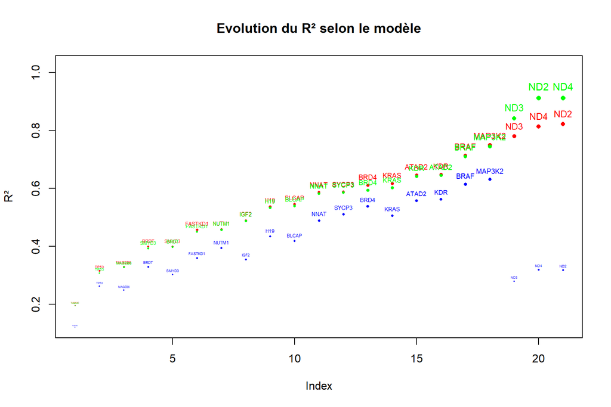

Les modèles réalisés avec les deux dernières méthodes sont bien plus efficaces pour ce qui est de la prédiction de la valeur d’expression de chaque gène. Ce qui est logique, car le nombre de paramètres est bien plus importante.

L’observation de l’évolution du R² nous permet de voir l’efficacité des modèles en général, nous pouvons voir que le pourcentage de variance expliqué par le modèle concernant les gènes ND2 à ND4 est bien plus important que les gènes TUBA3C ou MAGEB6. Mais surtout que la progression de ce pourcentage a été incomparable aux autres pour les gènes ND2 à ND4. Cela peut s’expliquer par la corrélation importante entre ces trois variables. En effet, selon la littérature scientifique ces 3 gènes on des fonctions moléculaire similaire en plus de faire partie du même processus biologique (la mitochondrie). Toutefois on peut surtout voir que plusieurs modèles garde un R² relativement faible (<0.5), pour le taux d’erreur n’est pas si élevé lors des résultats, il se peut donc qu’il n’y est pas besoin d’un modèle particulièrement puissant pour ces gènes.

De plus, le premier modèle nous permettait d’avoir un score sur codalab de 1.54, qui était le score médian des participants. Alors que le second et le troisième modèle nous permettent d’atteindre un score de 1.23, qui est bien classé dans la compétition.

## C : Interprétation de nos résultats

Globalement, on peut voir que chaque gène contient dans son modèle de prédiction au moins un autre gènes d’une famille différente, en conséquent on peut déduire la valeur d’expression d’un gène en fonction d’un autre (en partie) mais aussi de l’age, le sexe, le fait que le tissue soit tumoral ou non etc… La réalisation du modèle et des statistiques descriptive aura permis aussi de voir que seul les gènes concernant l’activité mitchondrique on un lien fort entre eux, c’est le cas aussi pour les autres mais dans une moindre mesure.

En résumant le tableau précédents concernants les paramètres de chaque modèle (pour le modele 2), on voit que les gènes les moins utilisés dans les modèles sont les gènes SYCP3, H19, NUTM1, TP53, des gènes qui n’ont pourtant pas les mêmes fonctions. D’un point de vu général, les autres semblent avoir la même importance. Seule la variable concernant le projet est constamment utilisée pour la prédiction de la valeur d’expression d’un gène.

|  | sex | tissue_status | project | tissue | ATAD2 | SYCP3 | H19 | IGF2 | NNAT | BLCAP | BRD4 | BRDT | NUTM1 | MAGEB6 | TUBA3C | SMYD3 | MAP3K2 | KDR | TP53 | KRAS | BRAF | FASTKD1 | ND2 | ND3 | ND4 |
| --- | --- | --- | --- | --- | --- | --- | --- | --- | --- | --- | --- | --- | --- | --- | --- | --- | --- | --- | --- | --- | --- | --- | --- | --- | --- |
|  | :14 | : 5 | x:21 | : 4 | : 2 | : 8 | : 7 | : 4 | : 4 | : 5 | : 5 | : 5 | : 7 | : 5 | : 6 | : 2 | : 2 | : 4 | : 7 | : 5 | : 4 | : 6 | : 5 | : 6 | : 5 |
|  | x: 7 | x:16 | NA | x:17 | x:19 | x:13 | x:14 | x:17 | x:17 | x:16 | x:16 | x:16 | x:14 | x:16 | x:15 | x:19 | x:19 | x:17 | x:14 | x:16 | x:17 | x:15 | x:16 | x:15 | x:16 |

Alors que lorsqu’on regarde la repartition des paramêtre dans le dernier modèle, on peut voir qu’il y a bien moins de paramêtres qui rentrent en compte. Notamment pour ND3, ND4 et MP3K2. Pourtant le score obtenu sur Codalab est le même, ce dernier modèle est donc plus précis, le second risquait d’être en surapprentissage sans vraiment avoir de moyen de le vérifier.

|  | sex | tissue_status | project | tissue | ATAD2 | SYCP3 | H19 | IGF2 | NNAT | BLCAP | BRD4 | BRDT | NUTM1 | MAGEB6 | TUBA3C | SMYD3 | MAP3K2 | KDR | TP53 | KRAS | BRAF | FASTKD1 | ND2 | ND3 | ND4 |
| --- | --- | --- | --- | --- | --- | --- | --- | --- | --- | --- | --- | --- | --- | --- | --- | --- | --- | --- | --- | --- | --- | --- | --- | --- | --- |
|  | :13 | : 3 | x:21 | : 5 | :21 | : 8 | : 5 | : 4 | : 5 | : 5 | : 4 | : 4 | : 7 | : 6 | : 5 | : 3 | :12 | : 4 | : 6 | : 7 | :10 | : 8 | :11 | :16 | :19 |
|  | x: 8 | x:18 | NA | x:16 | NA | x:13 | x:16 | x:17 | x:16 | x:16 | x:17 | x:17 | x:14 | x:15 | x:16 | x:18 | x: 9 | x:17 | x:15 | x:14 | x:11 | x:13 | x:10 | x: 5 | x: 2 |

Pour aller plus loin, il pourrait être intéressant d’ajouter des variables au jeu de données, en effet, en regardant le taux d’erreur sur certains gènes dans les résultats de tous les participants, on peut voir que celui ci est très élevé. En conséquent, malgré les multiples modèles différents de chacun, il manque obligatoirement des informations (notamment pour les gènes H19 et IGF2, qui ont un taux d’erreur de plus de 4). De plus afin d’améliorer le score global nous aurions pu alterner nos prédictions et nos imputation des Nas, ce qui aurait finalement pu converger vers une valeur plus précise.